# NLA17 Dissolved Gas Spatial Autocorrelation

J. Beaulieu

10/28/2019

## Background

During the 2017 National Lakes Assessment, dissolved gas samples and air samples were collected from the index site at each waterbody. Samples were analyzed for CO<sub>2</sub>, CH<sub>4</sub>, and N<sub>2</sub>O concentration via gas chromatography. The following is an analysis of spatial autocorrelation via lagged scatterplots

## Analysis

This .rmd assumes ‘DissolvedGasNla.prj’ working environment. Data is available as an sf and sp object.

```r
# Unique samples are identified by site.id and visit.no.  Some sites were sampled twice during the NLA17 index period.
# sample.source column discriminates between 'AIR' and dissolved gas 'DG" samples.  "AIR" samples were removed in
# readDissolvedGas.R.  Dissolved gas concentrations are reported in mol/L.

# Inspect sf object
dg.sf[ , c("site.id", "visit.no", "sample.source", "dissolved.co2", "dissolved.ch4", "dissolved.n2o")]
```

```
## Simple feature collection with 1219 features and 6 fields
## geometry type:  POINT
## dimension:      XY
## bbox:           xmin: -136.7813 ymin: 26.07154 xmax: -67.69865 ymax: 59.56787
## epsg (SRID):    4269
## proj4string:    +proj=longlat +ellps=GRS80 +towgs84=0,0,0,0,0,0,0 +no_defs
## First 10 features:
##           site.id visit.no sample.source dissolved.co2 dissolved.ch4
## 2  NLA17_AK-10023        1            DG     5.525e-05     6.685e-07
## 4  NLA17_AK-10083        1            DG     3.260e-05     4.305e-07
## 6  NLA17_AK-10086        1            DG     3.315e-05     6.350e-07
## 8  NLA17_AK-10125        1            DG     6.155e-06     3.215e-06
## 10 NLA17_AK-10245        1            DG     5.660e-05     7.440e-07
## 12 NLA17_AK-10281        1            DG     3.825e-05     4.580e-07
## 14 NLA17_AK-10327        1            DG     6.220e-05     5.945e-07
## 16 NLA17_AK-10329        1            DG    -5.665e-07     1.120e-07
## 18 NLA17_AK-10334        1            DG     2.490e-05     1.260e-06
## 20 NLA17_AK-10383        1            DG     3.245e-05     9.890e-07
##    dissolved.n2o                   geometry
## 2      9.755e-09 POINT (-132.9414 55.87976)
## 4      8.900e-09 POINT (-130.7358 55.50317)
## 6      1.260e-08 POINT (-136.0136 59.56787)
## 8      6.850e-09 POINT (-135.7317 58.44341)
## 10     9.630e-09 POINT (-133.4961 56.71852)
## 12     9.375e-09 POINT (-133.1797 56.77454)
## 14     9.900e-09   POINT (-132.957 55.8873)
## 16     7.680e-09 POINT (-134.4785 58.33422)
## 18     6.755e-09 POINT (-135.3376 59.13138)
## 20     9.420e-09 POINT (-133.1169 56.14224)
```

```r
# Inspect sp object
dg.sp[ , c("site.id", "visit.no", "sample.source", "dissolved.co2", "dissolved.ch4", "dissolved.n2o")]
```

```
## class       : SpatialPointsDataFrame
## features    : 1219
## extent      : -136.7813, -67.69865, 26.07154, 59.56787  (xmin, xmax, ymin, ymax)
## coord. ref. : +proj=longlat +ellps=GRS80 +datum=NAD83 +no_defs +towgs84=0,0,0
## variables   : 6
## # A tibble: 1,219 x 6
##    site.id visit.no sample.source dissolved.co2 dissolved.ch4 dissolved.n2o
##    <chr>      <int> <chr>                 <dbl>         <dbl>         <dbl>
##  1 NLA17_~        1 DG              0.0000552     0.000000668 0.00000000976
##  2 NLA17_~        1 DG              0.0000326     0.000000430 0.0000000089
##  3 NLA17_~        1 DG              0.0000332     0.000000635 0.0000000126
##  4 NLA17_~        1 DG              0.00000616    0.00000322  0.00000000685
##  5 NLA17_~        1 DG              0.0000566     0.000000744 0.00000000963
##  6 NLA17_~        1 DG              0.0000382     0.000000458 0.00000000938
##  7 NLA17_~        1 DG              0.0000622     0.000000594 0.0000000099
##  8 NLA17_~        1 DG             -0.000000566   0.000000112 0.00000000768
##  9 NLA17_~        1 DG              0.0000249     0.00000126  0.00000000676
## 10 NLA17_~        1 DG              0.0000324     0.000000989 0.00000000942
## # ... with 1,209 more rows
```

Bubble plots are a useful tool for visualizing spatial patterns. Dissolved CH4 and N2O don’t display obvious spatial patterns, but dissolved CO2 seems to greater along east coast, upper midwest, and a SW by NE transect between Texas and Wisconsin. Pretty interesting.

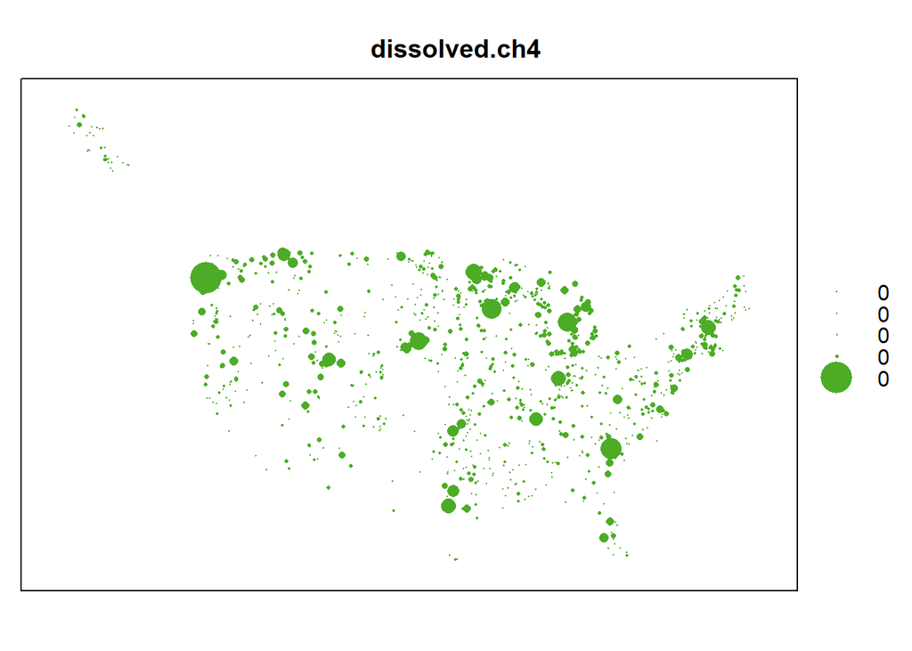

```r
# bubble function requires sp object and can't handle missing values.
bubble(dg.sp[!is.na(dg.sp$dissolved.ch4), "dissolved.ch4"]) #
```

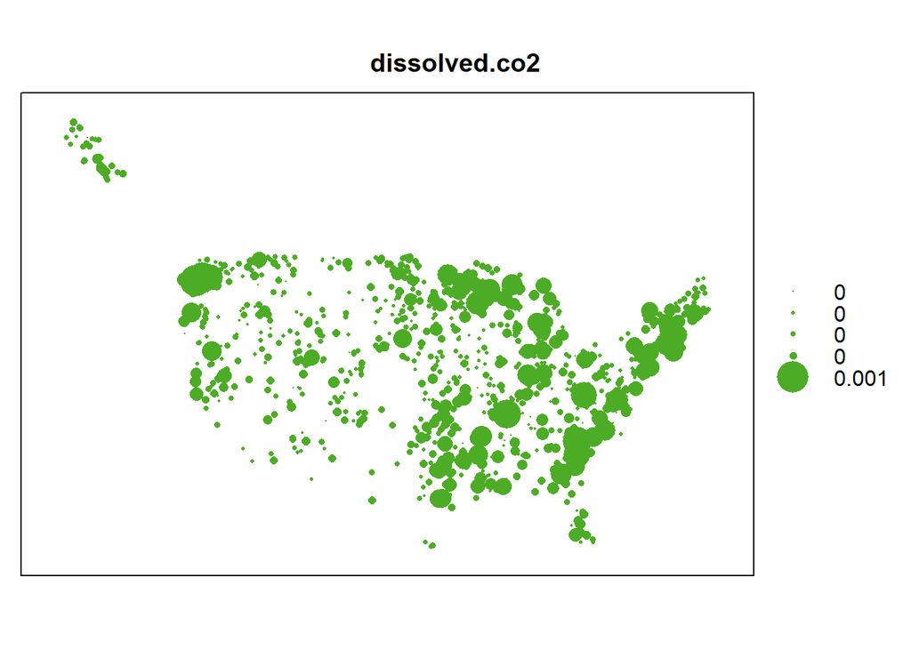

```r
bubble(dg.sp[!is.na(dg.sp$dissolved.co2), "dissolved.co2"])
```

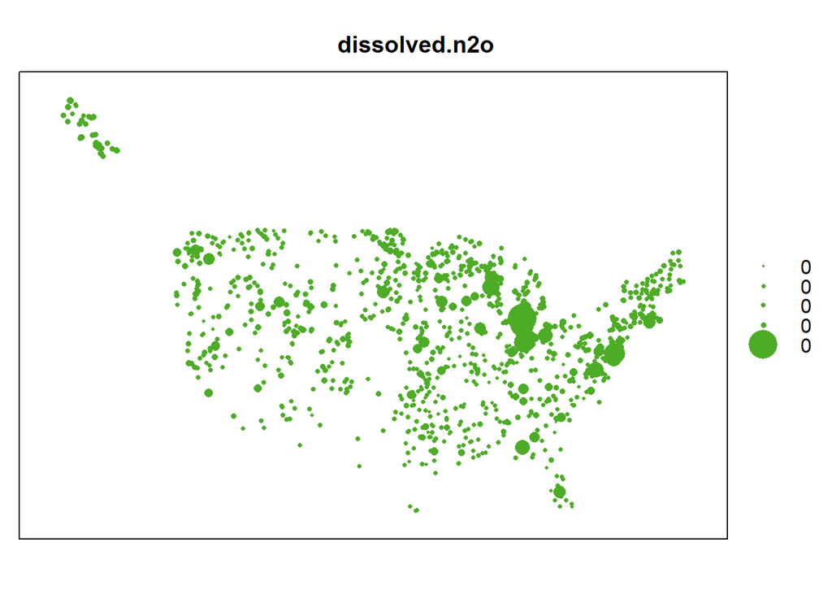

```r
bubble(dg.sp[!is.na(dg.sp$dissolved.n2o), "dissolved.n2o"])
```

Lagged scatterplots are a useful tool for detecting spatial autocorrelation. Evidence for spatial autocorrelation is stronger correltation among close vs. distant pairs of observations. This pattern is not evident for any of the gases.

```r
# Need to select appropriate distance bins.
# What are distance between points in the data?
gdis <- spDists(dg.sp)
max(gdis) # 5617, this must be km.  5617 km = 3490 miles, AK to FL
```

```
## [1] 5617.279
```

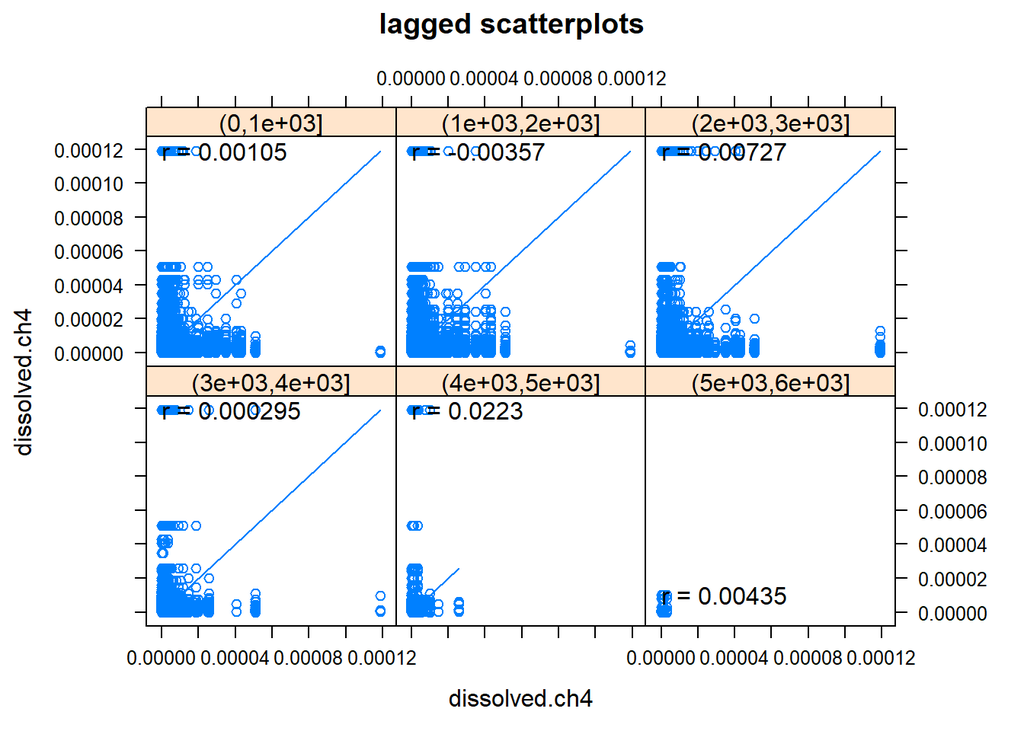

```r
hscat(dissolved.ch4 ~ 1,
      dg.sp[!is.na(dg.sp$dissolved.ch4), ], # remove missing
      # 5617275m = 3490 miles. AK to FL
      c(0, 1000, 2000, 3000, 4000, 5000, 6000))
```

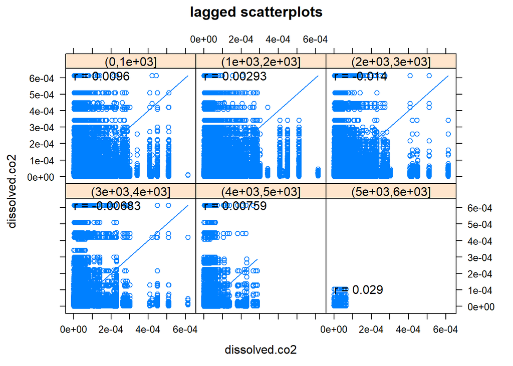

```r
hscat(dissolved.co2 ~ 1,
      dg.sp[!is.na(dg.sp$dissolved.co2), ], # remove missing
      # 5617275m = 3490 miles. AK to FL
      c(0, 1000, 2000, 3000, 4000, 5000, 6000))
```

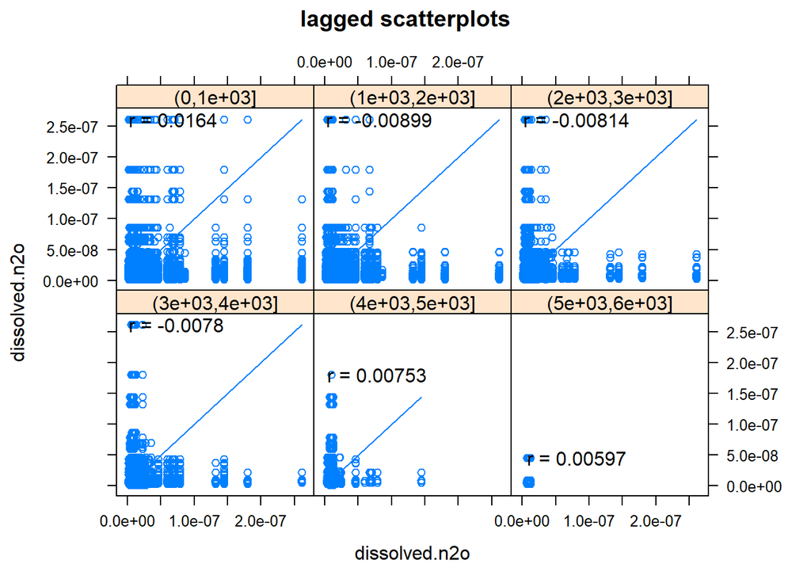

```r
hscat(dissolved.n2o ~ 1,
      dg.sp[!is.na(dg.sp$dissolved.n2o), ], # remove missing
      # 5617275m = 3490 miles. AK to FL
      c(0, 1000, 2000, 3000, 4000, 5000, 6000))
```

Perhaps spatial autocoreltation is more apparent within particular ecoregions. Can we do lagged scatterplots by ecoregion?

```r
# Loop to create lagged scatterplot by ecoregion x gas.  Not working yet....
# Need to customize size bins per ecoregion, I think.
# for(i in 1:length(unique(dg.sp@data$WSA9_NAME))) {
#   WSA9.i <- unique(dg.sp@data$WSA9_NAME)[i]
#   dg.sp.i <- filter(dg.sp, WSA9_NAME == WSA9.i)
#   gDis.1 <- spDists(dg.sp.i)
#   gDis.2 <- seq(from = 0, to = max(gDis.1), by = max(gDis.1) / 6)
#
#   for(j in 1:3) {
#     gas.j <- c("dissolved.ch4", "dissolved.co2", "dissolved.n2o")[j]
#     dg.sp.i.j <- filter(dg.sp.i, !is.na(gas.j)) # remove missing
#
#     hscat(gas.j ~ 1,
#           dg.sp.i,
#           gDis.2)
#   }
#
# }
```